# Modelled avian bioregion and environmental-response PCA

WM

2026-05-05

## Aim

This notebook focuses on modelled avian community structure through time. It contains two linked analyses:

- modelled bioregion shifts: define Atlas 1 reference community types from HMSC predicted species probability vectors, then assign Atlas 2 and Atlas 3 grid cells to those same reference types
- species environmental-response PCA: ordinate species by their HMSC environmental beta parameters, using Atlas 1 as the reference response space

Both analyses use HMSC modelled outputs only.

## Modelled Avian Bioregion Shifts

This analysis treats Atlas 1 as a reference community map. It first defines discrete clusters from Atlas 1 modelled species probability vectors, then assigns Atlas 2 and Atlas 3 communities to those same reference community types. A retained cell is compositionally closest to the same Atlas 1 cluster; a shifted cell is closer to another Atlas 1 cluster.

Species and site dimensions used for modelled bioregion analysis.

| atlas | n_sites | n_species |
| --- | --- | --- |
| 1 | 1776 | 157 |
| 2 | 1850 | 157 |
| 3 | 1904 | 157 |

Atlas 1 PAM/k-medoids diagnostics across candidate numbers of bioregions.

| k | mean_silhouette | min_cluster_n | min_cluster_prop |
| --- | --- | --- | --- |
| 3 | 0.206 | 401 | 0.226 |
| 4 | 0.159 | 368 | 0.207 |
| 5 | 0.166 | 154 | 0.087 |
| 6 | 0.157 | 156 | 0.088 |
| 7 | 0.152 | 131 | 0.074 |
| 8 | 0.142 | 138 | 0.078 |

Matched and unmatched grid cells across atlas periods.

[output not shown]

Validation that Atlas 1 nearest-medoid assignment reproduces the Atlas 1 reference clustering.

| n_reference_sites | n_validation_matches | validation_match_rate |
| --- | --- | --- |
| 1776 | 1776 | 1 |

Reference cluster retention and reassignment summaries.

| reference_bioregion | target_period | n_reference_sites | n_retained | pct_retained | n_reassigned | pct_reassigned | dominant_destination | mean_assignment_margin |
| --- | --- | --- | --- | --- | --- | --- | --- | --- |
| Cluster 1 | 1990s | 391 | 218 | 0.558 | 173 | 0.442 | Cluster 2 | 0.041 |
| Cluster 2 | 1990s | 860 | 799 | 0.929 | 61 | 0.071 | Cluster 3 | 0.060 |
| Cluster 3 | 1990s | 475 | 245 | 0.516 | 230 | 0.484 | Cluster 2 | 0.038 |
| Cluster 1 | 2010s | 401 | 141 | 0.352 | 260 | 0.648 | Cluster 2 | 0.035 |
| Cluster 2 | 2010s | 879 | 870 | 0.990 | 9 | 0.010 | Cluster 1 | 0.064 |
| Cluster 3 | 2010s | 496 | 100 | 0.202 | 396 | 0.798 | Cluster 2 | 0.034 |

## Manuscript Methods

We used HMSC modelled species occurrence probabilities to evaluate whether avian community structure shifted among atlas periods. For each atlas period, we extracted the predicted species probability vector for every grid cell and retained only species shared across all modelled outputs. Predicted community vectors were transformed using the Hellinger transformation by first dividing each grid cell’s predicted probabilities by its total predicted probability across species and then taking the square root. This transformation treats the data as community composition while reducing the influence of very common species.

Atlas 1 was used as the reference period for defining community clusters. We calculated Bray-Curtis dissimilarities among Hellinger-transformed Atlas 1 grid cells and clustered them using partitioning around medoids. Candidate solutions from three to eight clusters were compared using mean silhouette width, while excluding solutions with very small clusters (<3% of Atlas 1 grid cells). The selected Atlas 1 medoids were then kept fixed as reference community types. For Atlas 2 and Atlas 3, each grid cell was assigned to the nearest Atlas 1 medoid using Bray-Curtis dissimilarity. Assignment confidence was summarized as the difference between the nearest and second-nearest medoid distances, with the lowest 10% of margins flagged as low-confidence assignments.

To visualize directional changes in community composition, we fitted a PCA to the Hellinger-transformed Atlas 1 community matrix and projected Atlas 2 and Atlas 3 communities into the same ordination space. Cluster centroids were calculated separately for each atlas period in this reference PCA space. We summarized temporal change using maps of projected cluster membership, the percentage of grid cells assigned to each cluster, transition tables from the Atlas 1 reference clusters to later atlas assignments, and centroid movement in ordination space. As a sensitivity check on whether the ordination itself contained discrete structure, we also clustered the projected PCA point cloud directly using partitioning around medoids. Candidate solutions from two to eight PCA-space clusters were compared using mean silhouette width, and agreement between these unsupervised PCA clusters and the fixed reference clusters was summarized using the adjusted Rand index.

Species-level environmental-response structure was assessed separately from the grid-cell community clustering. For each atlas period, we extracted HMSC posterior mean beta parameters for the environmental predictors and multiplied each coefficient by the within-atlas standard deviation of the corresponding predictor. This converted coefficients to standardized effects, representing the expected response to a one-standard-deviation change in the environmental gradient available during that atlas period. Standardized effects were weighted by posterior certainty, defined as `2 * abs(Pr(beta > 0) - 0.5)`, so uncertain effects were shrunk towards zero. PCA was fitted to the weighted standardized beta matrix from Atlas 1, and Atlas 2 and Atlas 3 species response profiles were projected into that fixed reference space.

### Plain-Language Bioregion Workflow

The bioregion analysis asks whether Danish bird communities can be summarized as repeatable composition types, and whether grid cells have moved between those types through time. The input is the HMSC modelled species probability matrix for each atlas period. Rows are grid cells, columns are bird species, and each value is the predicted probability of occurrence. Thus, each grid cell is represented by a complete modelled community vector rather than by richness or by a single dominant species.

Before clustering, each grid cell’s predicted community vector was Hellinger-transformed. This means the predicted probabilities were converted to relative composition within the grid cell and then square-root transformed. This transformation keeps the focus on compositional differences among communities and reduces the tendency for high-richness cells or very common species to dominate the analysis.

Atlas 1 was treated as the baseline community map. Within Atlas 1, we calculated Bray-Curtis dissimilarity among all Hellinger-transformed communities and then used PAM/k-medoids clustering to identify discrete reference clusters. PAM was used because each cluster centre is a real grid-cell community, called a medoid, rather than an abstract average. Candidate values of `k` from 3 to 8 were compared with silhouette width, and the selected solution contained three clusters. These are labelled `Cluster 1`, `Cluster 2`, and `Cluster 3`.

Atlas 2 and Atlas 3 were not clustered independently. Instead, the Atlas 1 cluster medoids were kept fixed as reference community types. Each later grid cell was assigned to the nearest Atlas 1 medoid using Bray-Curtis dissimilarity. This means a later grid cell assigned to `Cluster 2` is interpreted as being more similar to the Atlas 1 `Cluster 2` community type than to the other Atlas 1 reference types. A change in cluster identity therefore means a movement towards another baseline community type, not the discovery of a new later-period cluster.

Assignment confidence was summarized using the distance margin between the nearest and second-nearest Atlas 1 medoids. If those two distances were similar, the grid cell was flagged as low confidence. These cells sit close to the boundary between community types, so apparent shifts in those places should be interpreted cautiously.

The ordination plots provide a visual summary of the same modelled community composition data. PCA was fitted to the Hellinger-transformed Atlas 1 communities, and Atlas 2 and Atlas 3 were projected into that fixed reference PCA space. The PCA does not define the clusters; it helps show whether the clusters occupy distinct regions of composition space and whether their centroids drift directionally over time.

## Cluster Maps And Ordination

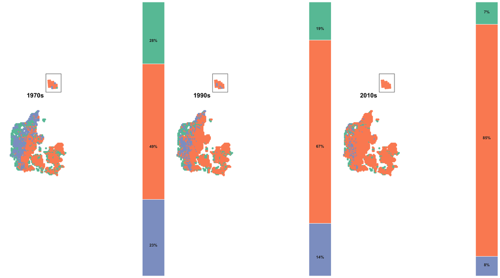

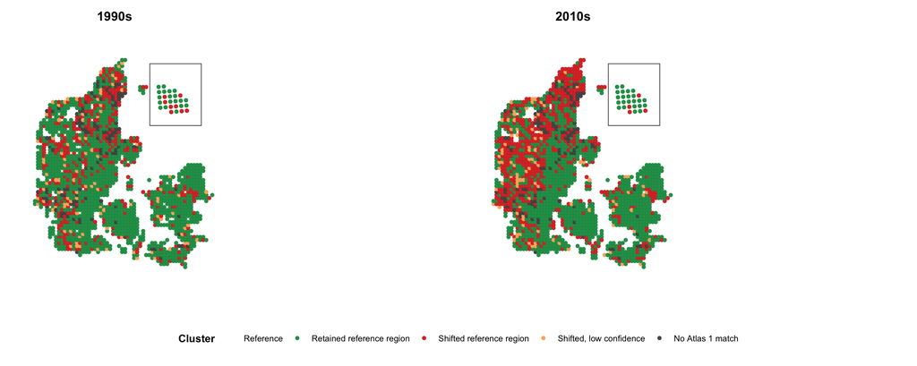

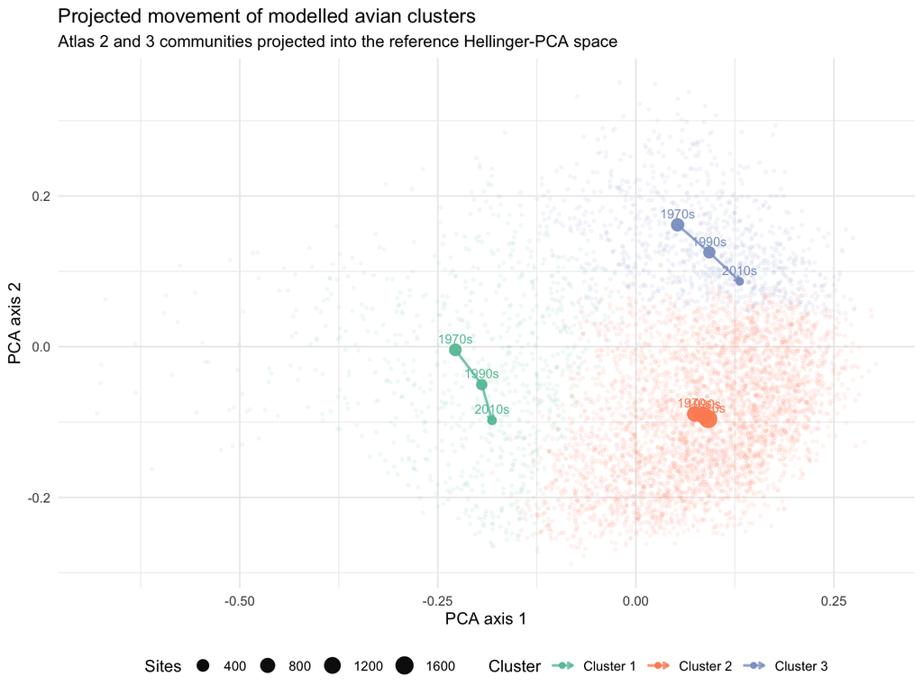

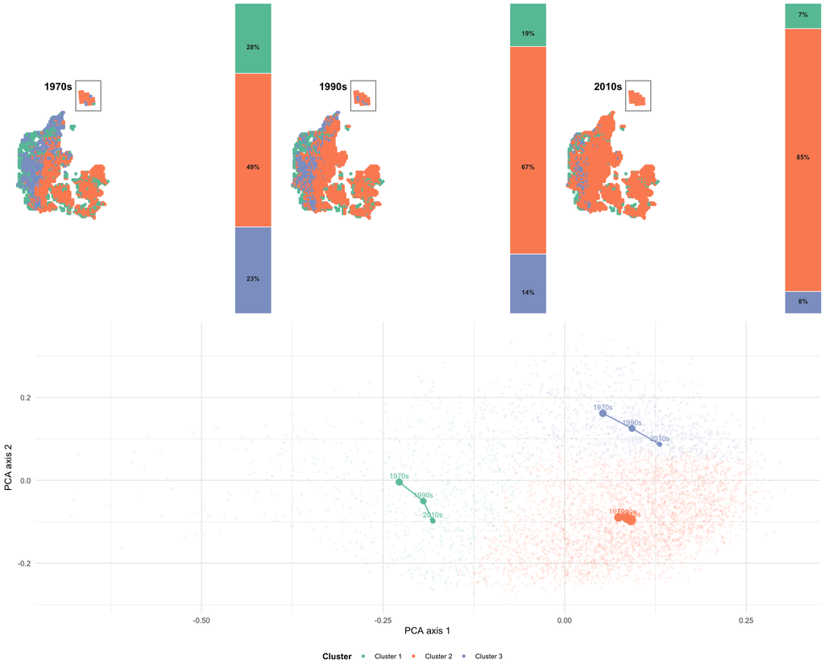

Low-confidence shifts are cells where the nearest and second-nearest reference bioregions are very similar, so those changes should be treated cautiously.

## PCA Point-Cloud Separation Diagnostics

The fixed clusters above are useful because they keep Atlas 1 as the baseline. This diagnostic asks a slightly different question: if the projected community points are clustered directly in PCA space, do they form clearly separated groups?

PAM/k-medoids diagnostics for projected community points using 5 PCA axes.

| k | mean_silhouette | min_cluster_n | min_cluster_prop | scope |
| --- | --- | --- | --- | --- |
| 2 | 0.237 | 821 | 0.462 | 1970s |
| 3 | 0.254 | 424 | 0.239 | 1970s |
| 4 | 0.218 | 258 | 0.145 | 1970s |
| 5 | 0.203 | 195 | 0.110 | 1970s |
| 6 | 0.192 | 140 | 0.079 | 1970s |
| 7 | 0.192 | 132 | 0.074 | 1970s |
| 8 | 0.187 | 132 | 0.074 | 1970s |
| 2 | 0.247 | 842 | 0.455 | 1990s |
| 3 | 0.225 | 471 | 0.255 | 1990s |
| 4 | 0.204 | 387 | 0.209 | 1990s |
| 5 | 0.215 | 218 | 0.118 | 1990s |
| 6 | 0.206 | 178 | 0.096 | 1990s |
| 7 | 0.187 | 154 | 0.083 | 1990s |
| 8 | 0.180 | 151 | 0.082 | 1990s |
| 2 | 0.283 | 831 | 0.436 | 2010s |
| 3 | 0.203 | 577 | 0.303 | 2010s |
| 4 | 0.198 | 452 | 0.237 | 2010s |
| 5 | 0.199 | 292 | 0.153 | 2010s |
| 6 | 0.209 | 177 | 0.093 | 2010s |
| 7 | 0.191 | 181 | 0.095 | 2010s |
| 8 | 0.190 | 108 | 0.057 | 2010s |
| 2 | 0.230 | 2615 | 0.473 | All atlas periods |
| 3 | 0.209 | 1487 | 0.269 | All atlas periods |
| 4 | 0.203 | 979 | 0.177 | All atlas periods |
| 5 | 0.181 | 864 | 0.156 | All atlas periods |
| 6 | 0.185 | 592 | 0.107 | All atlas periods |
| 7 | 0.178 | 316 | 0.057 | All atlas periods |
| 8 | 0.170 | 314 | 0.057 | All atlas periods |

Agreement between unsupervised PCA-space clusters and fixed reference clusters.

| period | n_sites | adjusted_rand_index | mean_silhouette |
| --- | --- | --- | --- |
| 1970s | 1776 | 0.198 | 0.253 |
| 1990s | 1850 | 0.095 | 0.230 |
| 2010s | 1904 | 0.022 | 0.208 |
| All atlas periods | 5530 | 0.085 | 0.230 |

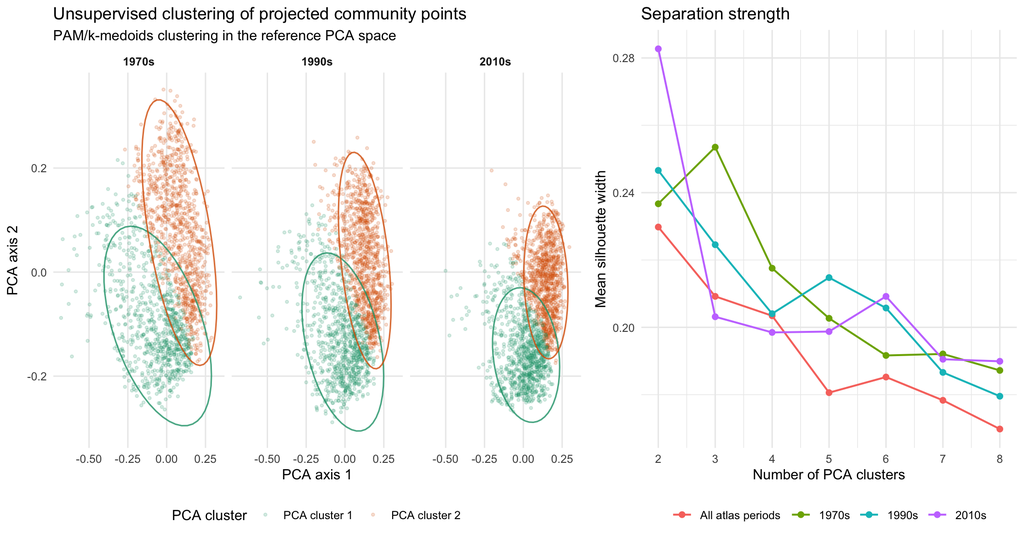

Interpretation: high silhouette values would indicate discrete, well-separated groups in the ordination. Low or moderate values indicate that the modelled communities are better understood as a gradient, even if it is still useful to summarize that gradient with fixed reference clusters.

## Species Environmental Response PCA

This section asks whether the way species respond to the environmental gradients shifted through time. Each species is represented by its HMSC environmental beta coefficients. The coefficients are converted to standardized effects before PCA:

`standardized beta = posterior mean beta * within-atlas predictor SD`

The PCA therefore ordains species by their response to a one-standard-deviation change in each predictor within that atlas period. Coefficients are also weighted by posterior certainty, so uncertain effects are shrunk towards zero rather than removed with a hard threshold.

Species and predictor alignment for the HMSC beta-parameter PCA.

| atlas | period | n_species_in_workbook | n_common_species_used | n_predictors_used |
| --- | --- | --- | --- | --- |
| 1 | 1970s | 157 | 157 | 8 |
| 2 | 1990s | 157 | 157 | 8 |
| 3 | 2010s | 157 | 157 | 8 |

Main environmental-response gradients in the Atlas 1 beta PCA.

| axis | strongest_positive_loading | strongest_negative_loading | variance_explained |
| --- | --- | --- | --- |
| PC1 | Cropland (% coverage) | Temperature | 0.567 |
| PC2 | Precipitation | Urban (% coverage) | 0.165 |

Centroid movement of species environmental-response profiles in the Atlas 1 beta PCA space.

| atlas | period | PC1 | PC2 | n_species | delta_PC1_from_1970s | delta_PC2_from_1970s | distance_from_1970s |
| --- | --- | --- | --- | --- | --- | --- | --- |
| 1 | 1970s | 0.000 | 0.000 | 157 | 0.000 | 0.000 | 0.000 |
| 2 | 1990s | 0.002 | -0.029 | 157 | 0.002 | -0.029 | 0.029 |
| 3 | 2010s | 0.005 | -0.022 | 157 | 0.005 | -0.022 | 0.023 |

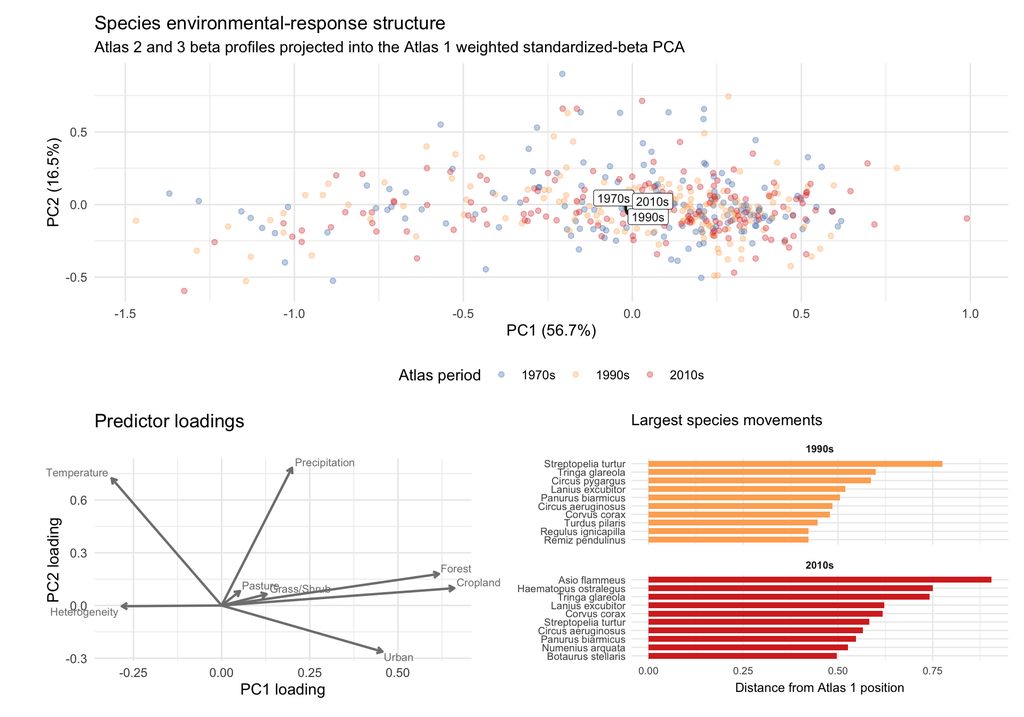

Interpretation: this ordination summarizes how species’ environmental responses are structured, not where species occur. Species close together have similar weighted standardized responses to the modelled environmental predictors. The centroid arrow shows whether the average species response profile moves away from the Atlas 1 baseline. The loading panel gives the ecological meaning of the axes: movement towards a predictor arrow means stronger positive association with that predictor, while movement in the opposite direction means stronger negative association. Because the coefficients were standardized with atlas-specific predictor standard deviations, these shifts describe response strength within the environmental variation available in each atlas period.